# Assignment QRM

Published

March 9, 2026

# 1. Propose marginal distribution functions for each of the four stocks

We inspect each of the distributions by looking at the marginal distributions.

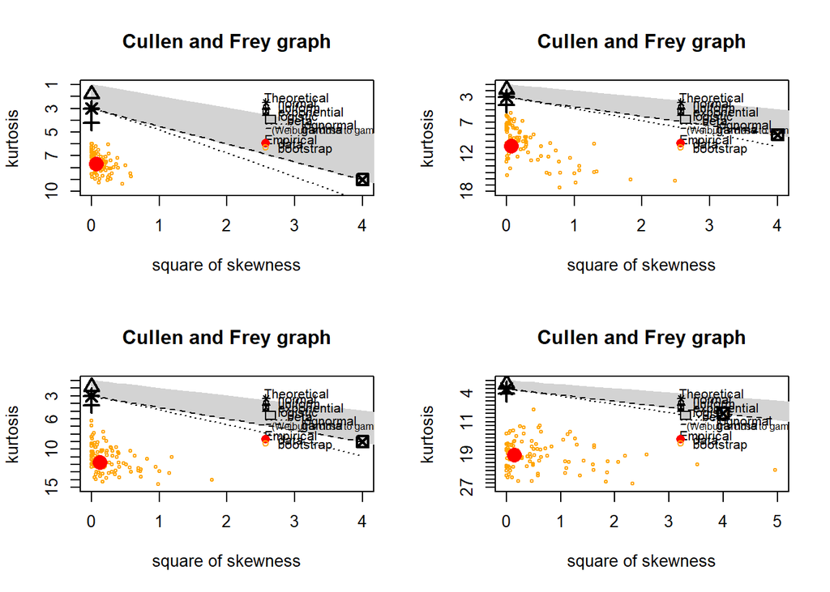

Here we have plottet respectively from top left to bottom right, GOOG, MSFT, MKR, IDU.

We have used the package **fitdistrplus** to plot the kurtosis vs the square of skewness. This should be a nice way to characterise the distributions. It measures the probability of extreme observations.

$$E[(X−μ)4](E[X−μ)2])2$$
We note that our distributions has a much larger kurtosis than that of a log-normal distribution.

Next to look at the asymmetry of the distributions, we look at the skewness.

$$E[(X−μ)3](E[X−μ)2])3/2$$
The are all around zero, which indicates that the distributions are quite symmetric.

Hence we will look at the t-distributions, since it can be parameterised with fatter tails, and still is symmetric.

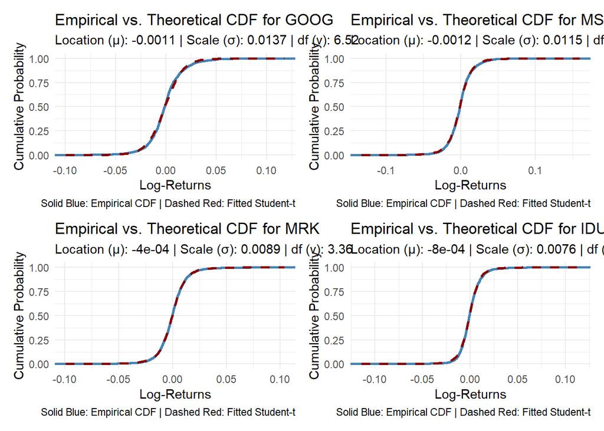

This fit looks very nice. And we decide to use this going forward.

# 2. Now use rigorous methods from extreme value theory to determine the upper tail distributions for the losses, and compare these with your proposed distributions in part (1). Do these EVT methods validate your previous choices? Explain

We would like to look at the mean excess and hill plot for our emprical data. We look at data which is positive and untill the $0.975$ quantile.

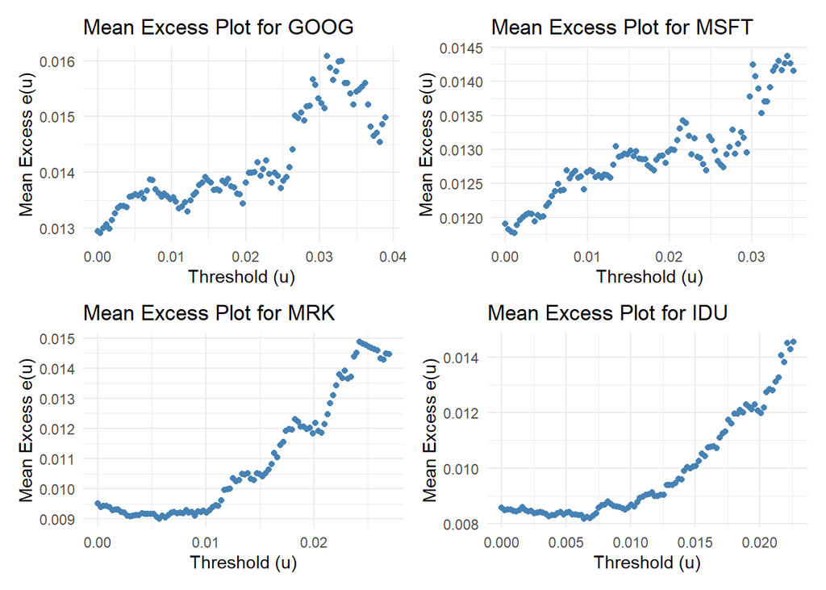

We would also like to look at the hills plots.

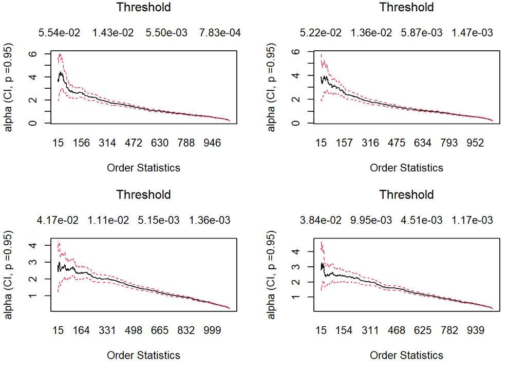

By visual inspection we choose $U=(0.025,0.017,0.01,0.01)$ for in the order given in the dataset.

We are asked to “compare these with your proposed distributions in part (1)” which we interpret as directly looking at how well each of the distributions compare for the tail data.

We can easily, with R and the **evir**, package look at the tail of the distribution. But we have to scale the t distribution to directly compare the cdf.

$$P(X≤t∣X>u)=P(X≤t∩X>u)P(X>u)=P(u<X≤t)P(X>u)=P(X≤t)−P(X≤u)P(X>u)$$

We then plot the cdf for the t-distribution with the one for the gpd, and the emprical data. The gpd is given by definition 2.2.7. Due to an implementation of the theoretical cdf of the t-distribution in R’s **stats::pt** we dont need to calculate anything here.

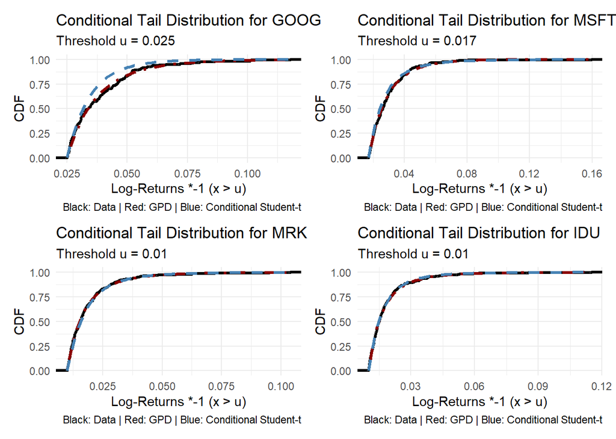

This shows that the t-distribution is surprisingly good at capturing the tail, compares to the direct modeling with the gpd. The only place where it is apparently worse is on GOOG. This might be due to a poorly choosen threshold. To conclude, the evt theory validates our previous choices.

# 3. Propose an elliptical distribution for the joint distribution for each of the two pairs.

From example 3.2.7 we have the multivariate-t-distribution, which we fit on the data. We want to simulate from this fit, and compare with the actual data to determine if this choice of distribution is good.

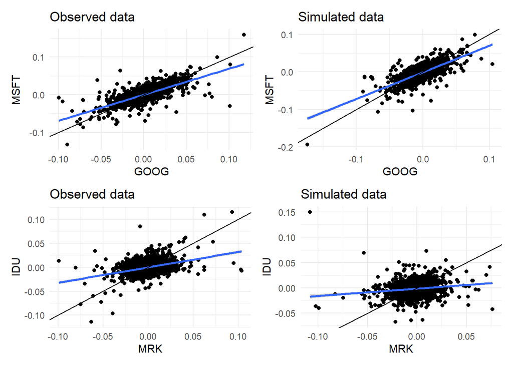

# 4. Next, consider an alternative approach using copulas. To this end, determine the marginal distributions as follows: (i) choose a generalised Pareto distribution for the large values, and (ii) use the empirical distribution for the small values (observing that these empirical distributions are “nearly” continuous when the number of observations is large). —-

Note that
$$P(X>t)=P(X>t∣X>u)P(X>u)=(1−P(X≤t∣X>u))P(X>u)=(1−Gγ,β(t−u))P(X>u)$$
Then
$$P(X≤t)=P(X>u)⏟†Gγ,β(x−u)$$
where $†$ is just numerically $#{Xi>u}n$ Then

$$F^n(t)=1t≤u[1n∑i=1n1Xi≤t]+1t≤uc[1−#{Xi>u}n(1+β−1γ⋅(t−u))−1/γ]$$

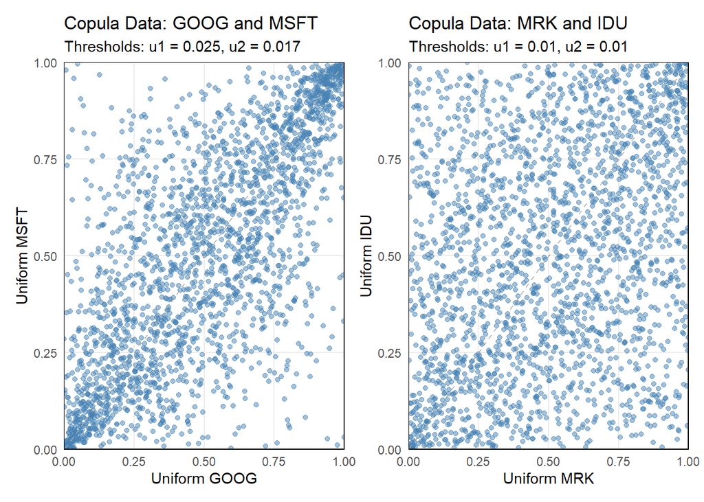

### GOOG vs MSFT

The left plot shows a positive correlation between the two tickers. For the extreme values $(0,0)$ and $(1,1)$ the points are closely packed, indicating strong tail depedence. This makes intuitively sense, since if the tech sector has a red days, both tickers probably move alike.

# 5. Next, using some exploratory analysis of, e.g., the coefficient of upper tail dependence and Kendall’s τ , determine to what extent the data has a tendency towards comonotonicity, countermonotonicity, or independence. Now propose a copula to model the joint distribution for each of the two pairs.

## Kendalls tau

```
[1] "Kendall's tau for GOOG and MSFT: 0.53 and for MRK and IDU: 0.2"
```

which supports our conclusions from 4.

## Coefficient of upper tail dependence

```
[1] "UTD for GOOG/MSFT: 0.55"
```

```
[1] "UTD for MRK/IDU: 0.19"
```

## Copula

We note that Kendall’s tau is much greater for the two tech stocks than for merck and the etf. Also the upper tail dependence shows the same pattern.

To determine if our proposed copulas are any good, we follow the method used on page 157 in the notes. We note
$$τ(X1,X2)=2πarcsinρ⟺ρ=sin(π2τ)$$

```
Call: copula::fitCopula(t_cop_gm, data = as.matrix(copula_data), method = "ml")
Fit based on "maximum likelihood" and 2302 2-dimensional observations.
t-copula, dim. d = 2
      Estimate Std. Error
rho.1    0.742      0.011
df       2.894      0.267
The maximized loglikelihood is 1017
Optimization converged
Number of loglikelihood evaluations:
function gradient
      44        9
```

```
Call: copula::fitCopula(gauss_cop_mi, data = as.matrix(copula_data2),
    method = "ml")
Fit based on "maximum likelihood" and 2302 2-dimensional observations.
Normal copula, dim. d = 2
      Estimate Std. Error
rho.1   0.3231      0.018
The maximized loglikelihood is 126.2
Optimization converged
Number of loglikelihood evaluations:
function gradient
      25        3
```

```
[1] "T-copula: rho = sin(pi * kendalls_tau /2) = 0.74"
```

```
[1] "G-copula: rho = sin(pi * kendalls_tau /2) = 0.31"
```

We note that we are very close to the observed rho, hence we think this is an acceptable fit.

# 6. As an alternative, determine the copula which is obtained from the Frechet bounds and describes the “worst-case” scenario —-

We have from proposition 4.1.5 the Frechet bounds, with $d=2$.

$$W(u,v)=max[u+v−1,0]M(u,v)=min[u,v]$$

The worst case is when the assets move together, since we then obtain no diversification advantages. The worst case is then the one with comonotonicity which is $min[u,v]$

# 7. Now write down the loss random variable for a portfolio where $10,000 is invested in each of the two stocks, both for the Merck/IDU portfolio and for the Google/Microsoft portfolio. Using this, calculate the Value-at-Risk for each of these portfolios using both the elliptical methods suggested in part (3) above, and the copula methods described in parts (4) and (5) above. In these calculations, choose α = 0.9999 (since these are daily returns). How do these different VaR estimates compare? —-

We know that the loss is $Xt,i=−logSt,i/St−1,i$ which implies that $St,i=St−1,ie−Xt,i$. Hence for a portfolio as ours with $w1=10000$ and $w2=10000$.
$$Lport=∑i=12Xiwi$$

## Elliptical methods

We now calculate the value at risk for each of these portfolios using first the elliptical methods. In (3) we proposed multivariate t-distributions. We Denote $L=m+atX$ where $a=w∈R2$ and $m=0$ recall the set $MX$ from the notes. We then have that $X∼Ed(μ,Σ,ϕ)$ from (3) and $ρ$ is set to the value at risk. Thus for our alpha $ρ$ fulfills the conditions of theorem 3.2.10 (i)
$$ρ(L)=wtμ+wtΣwρ(Y)$$
where $Y∼S1(ϕ)$, this is $ρ(Y)=tv−1(α)$ since our $ϕ$ is the standard t distribution.

```
[1] "VAR GM: 4064.45"
```

```
[1] "VAR mi: 2012.84"
```

## Copula Methods

In (4) we used the empircal and the gpd, in (5) we used the gaussian and t-copula. We cannot find these analytically so we simulate.

```
[1] "Copula VaR GM: 2649.41"
```

```
[1] "Copula VaR MI: 2015.3"
```

### Summary of Value-at-Risk (99.99%) Estimates

| Portfolio | Elliptical Method (MVT) | Copula Method (with EVT) |
| --- | --- | --- |
| **GOOG & MSFT** | $4,064.45 | $2,649.41 *(t-copula)* |
| **MRK & IDU** | $2,012.84 | $2,015.30 *(Gaussian copula)* |

We note that the elliptical distribution for the GOOG & MSFT yields a far greater var than the copula method. For the gaussian case it does not matter since the both the methods are approximately the same.

# 8. Finally, draw conclusions about the efficacy of the different approaches, and comment on the challenges in applying the various methods in order to draw conclusions about the VaR.

1. Elliptical methods This method is very effective when looking at the computational speed and analytical results we have. Thanks to the results from the book we can easily simulate. There are some drawbacks, which is the symmetry and it forces all assets ot share the same tail parameter. Perhaps this can overestimate the risk.
2. Copula methods this is also a good method. We use the sklars theorem, and we find this method to be perhaps the most accurate.

Some of the challenges in applying these methods are how one shoudl choose the threshold in the gpd. We just eyeballed it based off of the plots. Also we have some data sparcity in the tails. One could perhaps have used the importance sampling method here. The copula method requires a bit more computational power. But for our study here, its not a problem.